# Visualizing Genomics Data

We can define a GeneRegionTrack as we would all other tracktypes. Here we provide a genome name, chromosome of interest and a name for the track.

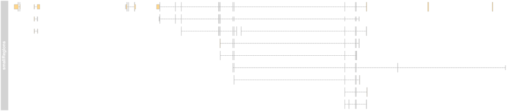

```r
grtrack <- GeneRegionTrack(geneModels, genome = "hg19",
                           chromosome = "chr7",
                           name = "smallRegions")
plotTracks(grtrack)
```

##GeneRegionTrack - Setting up the gene model track.

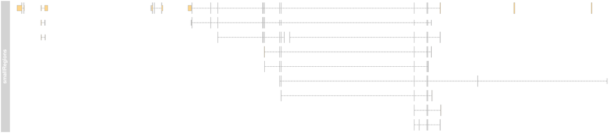

```r
plotTracks(grtrack)
```

We can see that features here are rendered slightly differently to those in an **AnnotationTrack** object.

Here direction is illustrated by arrows in introns and unstranslated regions are shown as narrower boxes.

##GeneRegionTrack - Specialised labelling.

Since gene models typically contain exon, transcript and gene level annotation we can specify how we wish to annotate our plots by using the **transcriptAnnotation** and **exonAnnotation** parameters.

To label all transcripts by the gene annotation we specify the gene column to the **transcriptAnnotation** parameter.

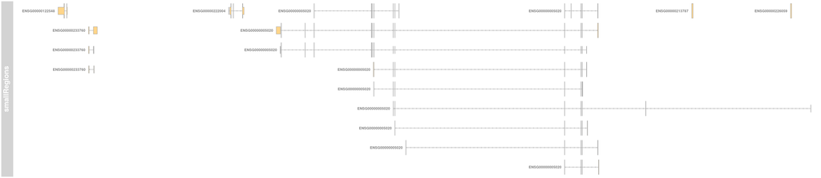

```r
plotTracks(grtrack,transcriptAnnotation="gene")
```

##GeneRegionTrack - Specialised labelling.

Similarly we can label transcripts by their individual transcript names.

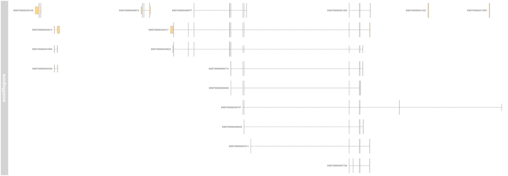

```r
plotTracks(grtrack,transcriptAnnotation="transcript")
```

##GeneRegionTrack - Specialised labelling.

Or we can label using the **transcriptAnnotation** object by any arbitary column where there is one level per transcript.

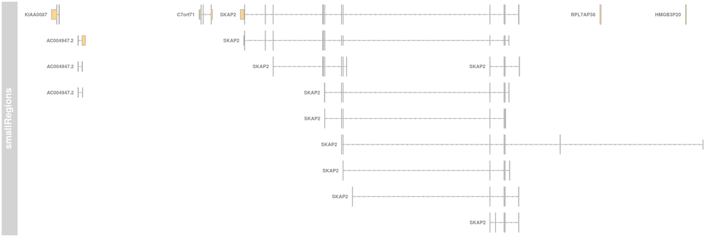

```r
plotTracks(grtrack,transcriptAnnotation="symbol")
```

##GeneRegionTrack - Specialised labelling of exons.

As with transcripts we can label individual features using the **exonAnnotation** parameter by any arbitary column where there is one level per feature/exon.

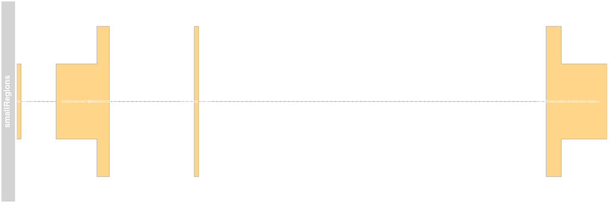

```r
plotTracks(grtrack,exonAnnotation="exon",
           from=26677490,to=26686889,cex=0.5)
```

##GeneRegionTrack - Specialized display density for gene models.

We saw that we can control the display density when plotting **AnnotationTrack** objects.

We can control the display density of GeneRegionTracks in the same manner.

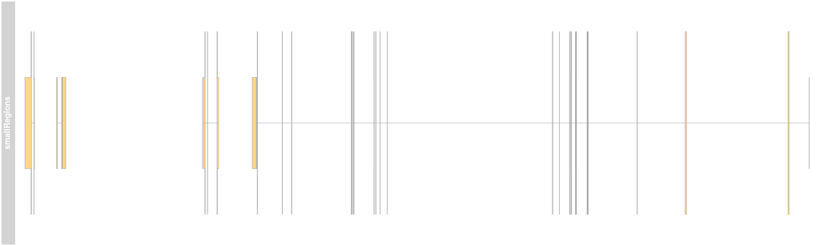

```r
plotTracks(grtrack, stacking="dense")
```

##GeneRegionTrack - Specialized display density for gene models.

However, since the **GeneRegionTrack** object is a special class of the **AnnotationTrack** object we have special parameter for dealing with display density of transcripts.

The **collapseTranscripts** parameter allows us a finer degree of control than that seen with **stacking** parameter. Here we set **collapseTranscripts** to be **TRUE** inorder to merge all overlapping transcripts.

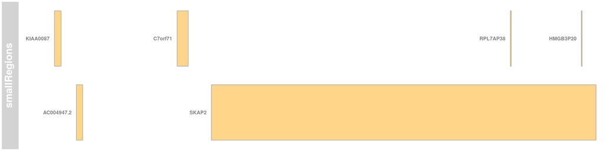

```r
plotTracks(grtrack, collapseTranscripts=T,
           transcriptAnnotation = "symbol")
```

##GeneRegionTrack - Specialized display density for gene models.

Collapsing using the **collapseTranscripts** has summarised our transcripts into their respective gene boundaries.

We have however lost information on the strand of transcripts. To retain this information we need to specify a new shape for our plots using the **shape** parameter. To capture direction we use the “arrow” shape

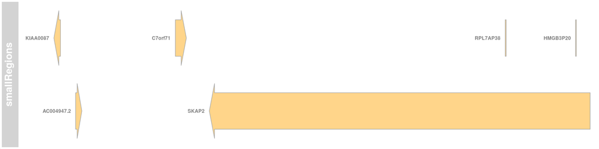

```r
plotTracks(grtrack, collapseTranscripts=T,
           transcriptAnnotation = "symbol",
           shape="arrow")
```

##GeneRegionTrack - Specialized display density for gene models.

The **collapseTranscripts** function also allows us some additional options by which to collapse our transcripts.

These methods maintain the intron information in the gene model and so get us closer to reproducing the “collapsed” feature in IGV.

Here we may collapse transcripts to the “longest”.

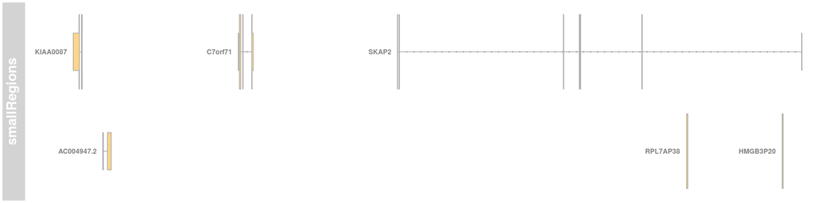

```r
plotTracks(grtrack, collapseTranscripts="longest",
           transcriptAnnotation = "symbol")
```

##GeneRegionTrack - Specialized display density for gene models.

Or we may specify to **collapseTranscripts** function to collapse by “meta”.

The “meta” option shows us a composite, lossless illustration of the gene models closest to that seen in “collapsed” IGV tracks.

Here importantly all exon information is retained.

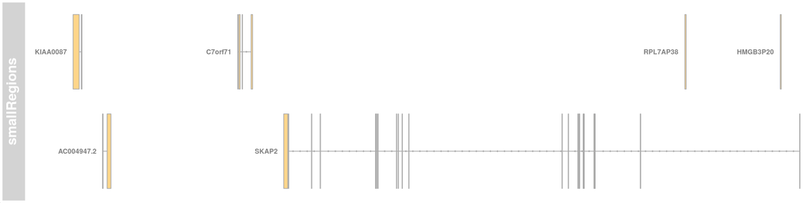

```r
plotTracks(grtrack, collapseTranscripts="meta",
           transcriptAnnotation = "symbol")
```

##GeneRegionTrack - Building your own gene models.

We have seen in previous material how gene models are organised in Bioconductor using the **TxDB** objects.

Gviz may be used in junction with **TxDB** objects to construct the **GeneRegionTrack** objects.

We saw in the Bioconductor and ChIPseq course that many genomes have pre-build gene annotation within the respective TxDB libraries. Here we will load a **TxDb** for hg19 from the **TxDb.Hsapiens.UCSC.hg19.knownGene** library.

```r
library(TxDb.Hsapiens.UCSC.hg19.knownGene)

txdb <- TxDb.Hsapiens.UCSC.hg19.knownGene
txdb
```

```
## TxDb object:
## # Db type: TxDb
## # Supporting package: GenomicFeatures
## # Data source: UCSC
## # Genome: hg19
## # Organism: Homo sapiens
## # Taxonomy ID: 9606
## # UCSC Table: knownGene
## # Resource URL: http://genome.ucsc.edu/
## # Type of Gene ID: Entrez Gene ID
## # Full dataset: yes
## # miRBase build ID: GRCh37
## # transcript_nrow: 82960
## # exon_nrow: 289969
## # cds_nrow: 237533
## # Db created by: GenomicFeatures package from Bioconductor
## # Creation time: 2015-10-07 18:11:28 +0000 (Wed, 07 Oct 2015)
## # GenomicFeatures version at creation time: 1.21.30
## # RSQLite version at creation time: 1.0.0
## # DBSCHEMAVERSION: 1.1
```

##GeneRegionTrack - Building your own gene models from a TxDb.

Now we have loaded our **TxDb** object and assigned it to *txdb*. We can use this **TxDb** object to construct our **GeneRegionTrack**. Here we focus on chromosome 7 again.

```r
customFromTxDb <- GeneRegionTrack(txdb,chromosome="chr7")
head(customFromTxDb)
```

```
## GeneRegionTrack 'GeneRegionTrack'
## | genome: hg19
## | active chromosome: chr7
## | annotation features: 6
```

##GeneRegionTrack - Building your own gene models from a TxDb.

With our new **GeneRegionTrack** we can now reproduce the gene models using the Bioconductor TxDb annotation.

Here the annotation is different but transcripts overlapping uc003syc are our SKAP2 gene.

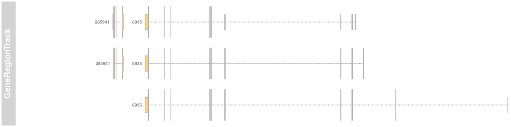

```r
plotTracks(customFromTxDb,
           from=26591341,to=27034958,
           transcriptAnnotation="gene")
```

##GeneRegionTrack - Building your own gene models from a GFF.

Now by combining the ability to create our own **TxDb** objects from GFFs we can create a very custom GeneRegionTrack from a GFF file. Here i use the UCSC table browser to extract a GTF of interest.

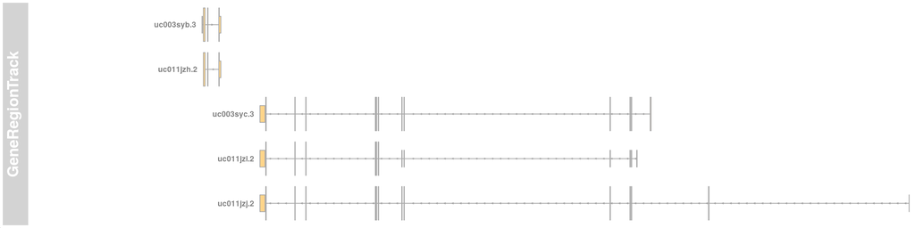

```r
library(GenomicFeatures)
ensembleGTF <- "data/hg19.gtf.gz"
txdbFromGFF <- makeTxDbFromGFF(file = ensembleGTF)
customFromTxDb <- GeneRegionTrack(txdbFromGFF,chromosome="chr7")
plotTracks(customFromTxDb,
           from=26591341,to=27034958,
           transcriptAnnotation="gene")
```

##Exercises

Time for exercises! Link here

##Solutions

Time for solutions! Link here